# aaron’s jazz music report

Updated: Jun 17, 2024 (15:44 MDT)

# About

I started listening to jazz music in 2020 and have been documenting the jazz releases that I’ve listened to since.

This webpage describes the various characteristics of these jazz releases using data from [Rate Your Music](https://www.rateyourmusic.com/) which has a database of 88,266 jazz releases (albums, EPs, singles).

# Quick Stats

Currently, I have listened to [766 jazz releases](https://rateyourmusic.com/collection/adnielsen/strm_h,ss.rd.e/Jazz).

#### Genres

- I listen to most frequently: [Avant-Garde Jazz](https://rateyourmusic.com/collection/adnielsen/strm_h,ss.rd/Avant-Garde+Jazz), [Hard Bop](https://rateyourmusic.com/collection/adnielsen/strm_h,ss.rd/Hard+Bop), Post-Bop, [Free Jazz](https://rateyourmusic.com/collection/adnielsen/strm_h,ss.rd/Free+Jazz), and [Spiritual Jazz](https://rateyourmusic.com/collection/adnielsen/strm_h,ss.rd/Spiritual+Jazz).
- I particularly enjoy: [Spiritual Jazz](https://rateyourmusic.com/collection/adnielsen/strm_h,ss.rd/Spiritual+Jazz), Stride, [Modal Jazz](https://rateyourmusic.com/collection/adnielsen/strm_h,ss.rd/Modal+Jazz), [Hard Bop](https://rateyourmusic.com/collection/adnielsen/strm_h,ss.rd/Hard+Bop) and Post-Bop.
- I tend to avoid: [Smooth Jazz](https://rateyourmusic.com/charts/popular/album/all-time/g:Smooth-Jazz/excl:ratings/), [Swing Revival](https://rateyourmusic.com/charts/popular/album/all-time/g:Swing-Revival/excl:ratings/), [Soul Jazz](https://rateyourmusic.com/charts/popular/album/all-time/g:Soul-Jazz/excl:ratings/), [British Dance Band](https://rateyourmusic.com/charts/popular/album/all-time/g:British-Dance-Band/excl:ratings/), and [Vocal Jazz](https://rateyourmusic.com/charts/popular/album/all-time/g:Vocal-Jazz/excl:ratings/).

#### Years

- I listen to most frequently: [1965](https://rateyourmusic.com/charts/top/album/1965/g:jazz/excl:ratings/), [1961](https://rateyourmusic.com/charts/top/album/1961/g:jazz/excl:ratings/), [1966](https://rateyourmusic.com/charts/top/album/1966/g:jazz/excl:ratings/), [1957](https://rateyourmusic.com/charts/top/album/1957/g:jazz/excl:ratings/), and [1959](https://rateyourmusic.com/charts/top/album/1959/g:jazz/excl:ratings/).
- I need to listen to more: [1960](https://rateyourmusic.com/charts/top/album/1960/g:jazz/excl:ratings/), [1976](https://rateyourmusic.com/charts/top/album/1976/g:jazz/excl:ratings/), [1994](https://rateyourmusic.com/charts/top/album/1994/g:jazz/excl:ratings/), [1980](https://rateyourmusic.com/charts/top/album/1980/g:jazz/excl:ratings/), and [1996](https://rateyourmusic.com/charts/top/album/1996/g:jazz/excl:ratings/).

#### Musicians

- I listen to most frequently: [John Coltrane](https://rateyourmusic.com/artist/john-coltrane), [Miles Davis](https://rateyourmusic.com/artist/miles-davis), [Thelonious Monk](https://rateyourmusic.com/artist/thelonious-monk), [Anthony Braxton](https://rateyourmusic.com/artist/anthony-braxton), and [Sun Ra](https://rateyourmusic.com/artist/sun-ra).
- My favorite jazz musician is [Anthony Braxton](https://rateyourmusic.com/artist/anthony-braxton) and my favorite jazz album is [Six Monk’s Compositions (1987)](https://rateyourmusic.com/release/album/anthony-braxton/six-monks-compositions-1987/).

# Jazz Albums Listened to by Genre

In the following table, MyCount is the number of albums I’ve listened to in the genre, PopCount is the number of albums in the RateYourMusic database in the genre, and LR is the likelihood ratio. LR > 1 means I listen to the genre more than expected based on the number of albums in the genre and LR < 1 means I listen to the genre less than expected.

| Genre | MyCount | PopCount | LR |
| --- | --- | --- | --- |
| [Avant-Garde Jazz](https://rateyourmusic.com/genre/Avant-Garde+Jazz) | [231](https://rateyourmusic.com/collection/adnielsen/strm_h/Avant-Garde+Jazz) | [14935](https://rateyourmusic.com/charts/popular/album/all-time/g:Avant-Garde-Jazz/excl:ratings/) | 1.78 |
| [Hard Bop](https://rateyourmusic.com/genre/Hard+Bop) | [110](https://rateyourmusic.com/collection/adnielsen/strm_h/Hard+Bop) | [2543](https://rateyourmusic.com/charts/popular/album/all-time/g:Hard-Bop/excl:ratings/) | 4.98 |
| Post-Bop | [109](https://rateyourmusic.com/collection/adnielsen/strm_h/Post-Bop) | [3080](https://rateyourmusic.com/charts/popular/album/all-time/g:Post-Bop/excl:ratings/) | 4.08 |
| [Free Jazz](https://rateyourmusic.com/genre/Free+Jazz) | [96](https://rateyourmusic.com/collection/adnielsen/strm_h/Free+Jazz) | [5660](https://rateyourmusic.com/charts/popular/album/all-time/g:Free-Jazz/excl:ratings/) | 1.95 |
| [Spiritual Jazz](https://rateyourmusic.com/genre/Spiritual+Jazz) | [78](https://rateyourmusic.com/collection/adnielsen/strm_h/Spiritual+Jazz) | [841](https://rateyourmusic.com/charts/popular/album/all-time/g:Spiritual-Jazz/excl:ratings/) | 10.69 |
| [Jazz Fusion](https://rateyourmusic.com/genre/Jazz+Fusion) | [60](https://rateyourmusic.com/collection/adnielsen/strm_h/Jazz+Fusion) | [11595](https://rateyourmusic.com/charts/popular/album/all-time/g:Jazz-Fusion/excl:ratings/) | 0.60 |
| Bebop | [44](https://rateyourmusic.com/collection/adnielsen/strm_h/Bebop) | [2512](https://rateyourmusic.com/charts/popular/album/all-time/g:Bebop/excl:ratings/) | 2.02 |
| [Cool Jazz](https://rateyourmusic.com/genre/Cool+Jazz) | [41](https://rateyourmusic.com/collection/adnielsen/strm_h/Cool+Jazz) | [2001](https://rateyourmusic.com/charts/popular/album/all-time/g:Cool-Jazz/excl:ratings/) | 2.36 |
| [Vocal Jazz](https://rateyourmusic.com/genre/Vocal+Jazz) | [36](https://rateyourmusic.com/collection/adnielsen/strm_h/Vocal+Jazz) | [9622](https://rateyourmusic.com/charts/popular/album/all-time/g:Vocal-Jazz/excl:ratings/) | 0.43 |
| [Modal Jazz](https://rateyourmusic.com/genre/Modal+Jazz) | [35](https://rateyourmusic.com/collection/adnielsen/strm_h/Modal+Jazz) | [538](https://rateyourmusic.com/charts/popular/album/all-time/g:Modal-Jazz/excl:ratings/) | 7.50 |
| [ECM Style Jazz](https://rateyourmusic.com/genre/ECM+Style+Jazz) | [34](https://rateyourmusic.com/collection/adnielsen/strm_h/ECM+Style+Jazz) | [1036](https://rateyourmusic.com/charts/popular/album/all-time/g:ECM-Style-Jazz/excl:ratings/) | 3.78 |
| [Big Band](https://rateyourmusic.com/genre/Big+Band) | [30](https://rateyourmusic.com/collection/adnielsen/strm_h/Big+Band) | [5895](https://rateyourmusic.com/charts/popular/album/all-time/g:Big-Band/excl:ratings/) | 0.59 |
| Swing | [25](https://rateyourmusic.com/collection/adnielsen/strm_h/Swing) | [4024](https://rateyourmusic.com/charts/popular/album/all-time/g:Swing/excl:ratings/) | 0.72 |
| Stride | [21](https://rateyourmusic.com/collection/adnielsen/strm_h/Stride) | [269](https://rateyourmusic.com/charts/popular/album/all-time/g:Stride/excl:ratings/) | 9.00 |
| Dixieland | [18](https://rateyourmusic.com/collection/adnielsen/strm_h/Dixieland) | [2089](https://rateyourmusic.com/charts/popular/album/all-time/g:Dixieland/excl:ratings/) | 0.99 |
| Jazz-Funk | [16](https://rateyourmusic.com/collection/adnielsen/strm_h/Jazz-Funk) | [3831](https://rateyourmusic.com/charts/popular/album/all-time/g:Jazz-Funk/excl:ratings/) | 0.48 |
| [Chamber Jazz](https://rateyourmusic.com/genre/Chamber+Jazz) | [16](https://rateyourmusic.com/collection/adnielsen/strm_h/Chamber+Jazz) | [1263](https://rateyourmusic.com/charts/popular/album/all-time/g:Chamber-Jazz/excl:ratings/) | 1.46 |
| [Third Stream](https://rateyourmusic.com/genre/Third+Stream) | [15](https://rateyourmusic.com/collection/adnielsen/strm_h/Third+Stream) | [645](https://rateyourmusic.com/charts/popular/album/all-time/g:Third-Stream/excl:ratings/) | 2.68 |
| Afro-Jazz | [10](https://rateyourmusic.com/collection/adnielsen/strm_h/Afro-Jazz) | [481](https://rateyourmusic.com/charts/popular/album/all-time/g:Afro-Jazz/excl:ratings/) | 2.40 |
| [Soul Jazz](https://rateyourmusic.com/genre/Soul+Jazz) | [9](https://rateyourmusic.com/collection/adnielsen/strm_h/Soul+Jazz) | [2546](https://rateyourmusic.com/charts/popular/album/all-time/g:Soul-Jazz/excl:ratings/) | 0.41 |
| [Latin Jazz](https://rateyourmusic.com/genre/Latin+Jazz) | [9](https://rateyourmusic.com/collection/adnielsen/strm_h/Latin+Jazz) | [1860](https://rateyourmusic.com/charts/popular/album/all-time/g:Latin-Jazz/excl:ratings/) | 0.56 |
| [Experimental Big Band](https://rateyourmusic.com/genre/Experimental+Big+Band) | [8](https://rateyourmusic.com/collection/adnielsen/strm_h/Experimental+Big+Band) | [725](https://rateyourmusic.com/charts/popular/album/all-time/g:Experimental-Big-Band/excl:ratings/) | 1.27 |
| [British Dance Band](https://rateyourmusic.com/genre/British+Dance+Band) | [7](https://rateyourmusic.com/collection/adnielsen/strm_h/British+Dance+Band) | [1952](https://rateyourmusic.com/charts/popular/album/all-time/g:British-Dance-Band/excl:ratings/) | 0.41 |
| [European Free Jazz](https://rateyourmusic.com/genre/European+Free+Jazz) | [7](https://rateyourmusic.com/collection/adnielsen/strm_h/European+Free+Jazz) | [950](https://rateyourmusic.com/charts/popular/album/all-time/g:European-Free-Jazz/excl:ratings/) | 0.85 |
| Ethio-Jazz | [7](https://rateyourmusic.com/collection/adnielsen/strm_h/Ethio-Jazz) | [276](https://rateyourmusic.com/charts/popular/album/all-time/g:Ethio-Jazz/excl:ratings/) | 2.92 |
| [Arabic Jazz](https://rateyourmusic.com/genre/Arabic+Jazz) | [7](https://rateyourmusic.com/collection/adnielsen/strm_h/Arabic+Jazz) | [203](https://rateyourmusic.com/charts/popular/album/all-time/g:Arabic-Jazz/excl:ratings/) | 3.97 |
| [Afro-Cuban Jazz](https://rateyourmusic.com/genre/Afro-Cuban+Jazz) | [6](https://rateyourmusic.com/collection/adnielsen/strm_h/Afro-Cuban+Jazz) | [676](https://rateyourmusic.com/charts/popular/album/all-time/g:Afro-Cuban-Jazz/excl:ratings/) | 1.02 |
| [Progressive Big Band](https://rateyourmusic.com/genre/Progressive+Big+Band) | [6](https://rateyourmusic.com/collection/adnielsen/strm_h/Progressive+Big+Band) | [363](https://rateyourmusic.com/charts/popular/album/all-time/g:Progressive-Big-Band/excl:ratings/) | 1.90 |
| [Smooth Jazz](https://rateyourmusic.com/genre/Smooth+Jazz) | [5](https://rateyourmusic.com/collection/adnielsen/strm_h/Smooth+Jazz) | [2832](https://rateyourmusic.com/charts/popular/album/all-time/g:Smooth-Jazz/excl:ratings/) | 0.20 |
| [Dark Jazz](https://rateyourmusic.com/genre/Dark+Jazz) | [5](https://rateyourmusic.com/collection/adnielsen/strm_h/Dark+Jazz) | [426](https://rateyourmusic.com/charts/popular/album/all-time/g:Dark-Jazz/excl:ratings/) | 1.35 |
| [Indo Jazz](https://rateyourmusic.com/genre/Indo+Jazz) | [5](https://rateyourmusic.com/collection/adnielsen/strm_h/Indo+Jazz) | [119](https://rateyourmusic.com/charts/popular/album/all-time/g:Indo-Jazz/excl:ratings/) | 4.84 |
| [Jazz manouche](https://rateyourmusic.com/genre/Jazz+manouche) | [4](https://rateyourmusic.com/collection/adnielsen/strm_h/Jazz+manouche) | [772](https://rateyourmusic.com/charts/popular/album/all-time/g:Jazz-manouche/excl:ratings/) | 0.60 |
| Samba-jazz | [3](https://rateyourmusic.com/collection/adnielsen/strm_h/Samba-jazz) | [729](https://rateyourmusic.com/charts/popular/album/all-time/g:Samba-jazz/excl:ratings/) | 0.47 |
| Marabi | [3](https://rateyourmusic.com/collection/adnielsen/strm_h/Marabi) | [312](https://rateyourmusic.com/charts/popular/album/all-time/g:Marabi/excl:ratings/) | 1.11 |
| [Spy Music](https://rateyourmusic.com/genre/Spy+Music) | [2](https://rateyourmusic.com/collection/adnielsen/strm_h/Spy+Music) | [116](https://rateyourmusic.com/charts/popular/album/all-time/g:Spy-Music/excl:ratings/) | 1.99 |
| [Cape Jazz](https://rateyourmusic.com/genre/Cape+Jazz) | [2](https://rateyourmusic.com/collection/adnielsen/strm_h/Cape+Jazz) | [116](https://rateyourmusic.com/charts/popular/album/all-time/g:Cape-Jazz/excl:ratings/) | 1.99 |
| [Crime Jazz](https://rateyourmusic.com/genre/Crime+Jazz) | [2](https://rateyourmusic.com/collection/adnielsen/strm_h/Crime+Jazz) | [82](https://rateyourmusic.com/charts/popular/album/all-time/g:Crime-Jazz/excl:ratings/) | 2.81 |
| [Swing Revival](https://rateyourmusic.com/genre/Swing+Revival) | [1](https://rateyourmusic.com/collection/adnielsen/strm_h/Swing+Revival) | [366](https://rateyourmusic.com/charts/popular/album/all-time/g:Swing-Revival/excl:ratings/) | 0.31 |
| Mbaqanga | [1](https://rateyourmusic.com/collection/adnielsen/strm_h/Mbaqanga) | [201](https://rateyourmusic.com/charts/popular/album/all-time/g:Mbaqanga/excl:ratings/) | 0.57 |
| [Jazz Poetry](https://rateyourmusic.com/genre/Jazz+Poetry) | [1](https://rateyourmusic.com/collection/adnielsen/strm_h/Jazz+Poetry) | [155](https://rateyourmusic.com/charts/popular/album/all-time/g:Jazz-Poetry/excl:ratings/) | 0.74 |
| [Flamenco Jazz](https://rateyourmusic.com/genre/Flamenco+Jazz) | [1](https://rateyourmusic.com/collection/adnielsen/strm_h/Flamenco+Jazz) | [118](https://rateyourmusic.com/charts/popular/album/all-time/g:Flamenco-Jazz/excl:ratings/) | 0.98 |
| Yass | [1](https://rateyourmusic.com/collection/adnielsen/strm_h/Yass) | [97](https://rateyourmusic.com/charts/popular/album/all-time/g:Yass/excl:ratings/) | 1.19 |
| [Cartoon Music](https://rateyourmusic.com/genre/Cartoon+Music) | [1](https://rateyourmusic.com/collection/adnielsen/strm_h/Cartoon+Music) | [65](https://rateyourmusic.com/charts/popular/album/all-time/g:Cartoon-Music/excl:ratings/) | 1.77 |
| Kwela | [1](https://rateyourmusic.com/collection/adnielsen/strm_h/Kwela) | [43](https://rateyourmusic.com/charts/popular/album/all-time/g:Kwela/excl:ratings/) | 2.68 |
| [Bulawayo Jazz](https://rateyourmusic.com/genre/Bulawayo+Jazz) | [1](https://rateyourmusic.com/collection/adnielsen/strm_h/Bulawayo+Jazz) | [12](https://rateyourmusic.com/charts/popular/album/all-time/g:Bulawayo-Jazz/excl:ratings/) | 9.60 |

# Jazz-ish Albums Listened to by Genre

A list of Jazz-adjacent genres.

| Genre | MyCount | PopCount | LR |
| --- | --- | --- | --- |
| [Modern Creative](https://rateyourmusic.com/genre/Modern+Creative) | [33](https://rateyourmusic.com/collection/adnielsen/strm_h/Modern+Creative) | [350](https://rateyourmusic.com/charts/popular/album/all-time/g:Modern-Creative/excl:ratings/) | 25.88 |
| [Free Improvisation](https://rateyourmusic.com/genre/Free+Improvisation) | [23](https://rateyourmusic.com/collection/adnielsen/strm_h/Free+Improvisation) | [13335](https://rateyourmusic.com/charts/popular/album/all-time/g:Free-Improvisation/excl:ratings/) | 0.47 |
| Jazz-Rock | [23](https://rateyourmusic.com/collection/adnielsen/strm_h/Jazz-Rock) | [5394](https://rateyourmusic.com/charts/popular/album/all-time/g:Jazz-Rock/excl:ratings/) | 1.17 |
| Ragtime | [12](https://rateyourmusic.com/collection/adnielsen/strm_h/Ragtime) | [1687](https://rateyourmusic.com/charts/popular/album/all-time/g:Ragtime/excl:ratings/) | 1.95 |
| [Nu Jazz](https://rateyourmusic.com/genre/Nu+Jazz) | [6](https://rateyourmusic.com/collection/adnielsen/strm_h/Nu+Jazz) | [2614](https://rateyourmusic.com/charts/popular/album/all-time/g:Nu-Jazz/excl:ratings/) | 0.63 |
| [Jazz Rap](https://rateyourmusic.com/genre/Jazz+Rap) | [4](https://rateyourmusic.com/collection/adnielsen/strm_h/Jazz+Rap) | [2815](https://rateyourmusic.com/charts/popular/album/all-time/g:Jazz-Rap/excl:ratings/) | 0.39 |
| [Jazz Pop](https://rateyourmusic.com/genre/Jazz+Pop) | [4](https://rateyourmusic.com/collection/adnielsen/strm_h/Jazz+Pop) | [2774](https://rateyourmusic.com/charts/popular/album/all-time/g:Jazz-Pop/excl:ratings/) | 0.40 |
| [Acid Jazz](https://rateyourmusic.com/genre/Acid+Jazz) | [2](https://rateyourmusic.com/collection/adnielsen/strm_h/Acid+Jazz) | [1219](https://rateyourmusic.com/charts/popular/album/all-time/g:Acid-Jazz/excl:ratings/) | 0.45 |
| Jazzstep | [1](https://rateyourmusic.com/collection/adnielsen/strm_h/Jazzstep) | [314](https://rateyourmusic.com/charts/popular/album/all-time/g:Jazzstep/excl:ratings/) | 0.87 |

# Most Jazz Releases Listened to by Artist

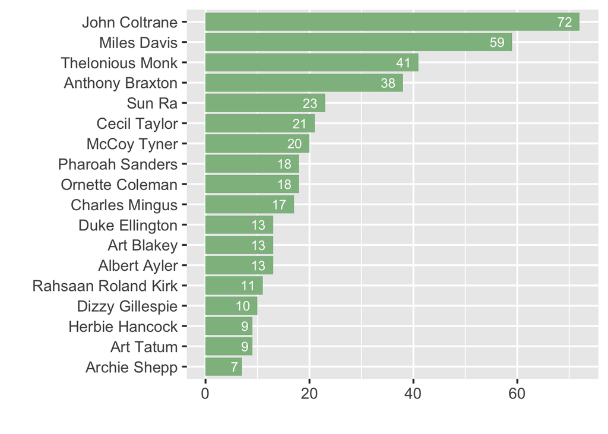

# Jazz Albums Listened to by Release Year

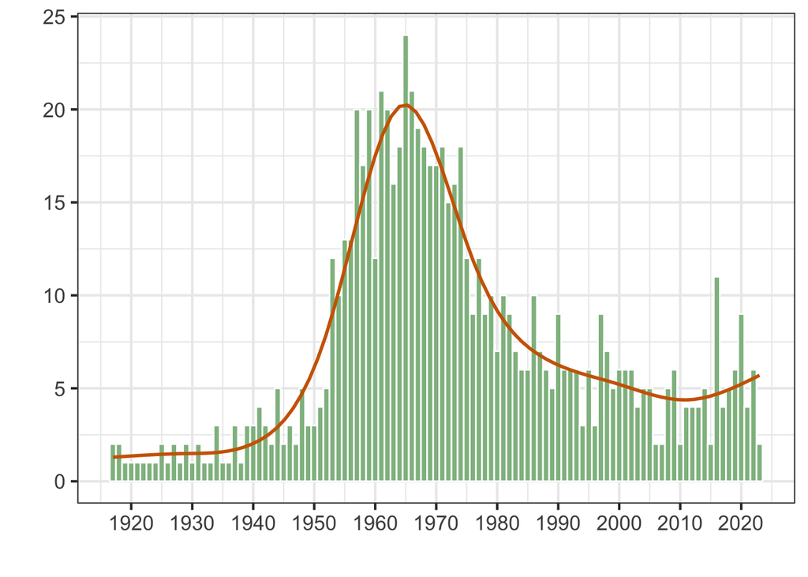

# Jazz Albums Listened to by Decade

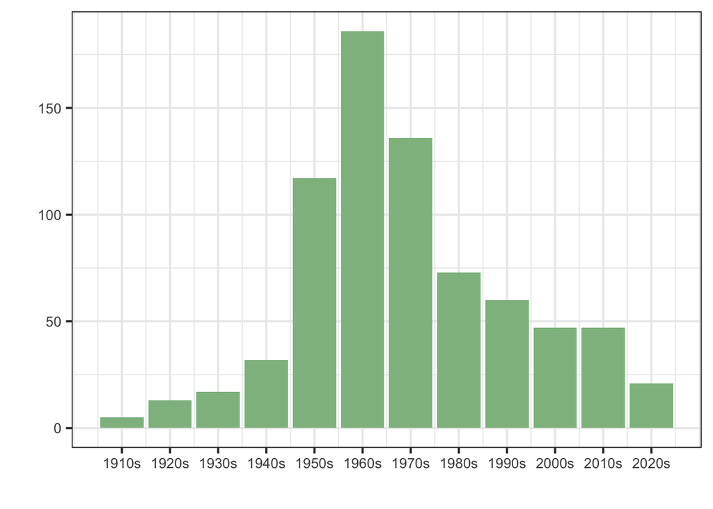

# Ten Jazz Album Favorites

| Artist | Album | Year | Genres |
| --- | --- | --- | --- |
| Anthony Braxton | Six Monk’s Compositions (1987) | 1988 | Bebop, Hard Bop |
| Anthony Braxton | Willisau (Quartet) 1991 | 1992 | Avant-Garde Jazz, Modern Creative |
| Charlie Mingus Jazz Workshop | Pithecanthropus erectus | 1956 | Post-Bop |
| John Coltrane | Coltrane “Live” at the Village Vanguard | 1962 | Modal Jazz, Hard Bop |
| Miles Davis | In a Silent Way | 1969 | Jazz Fusion, Modal Jazz |
| Ornette Coleman | The Shape of Jazz to Come | 1959 | Avant-Garde Jazz |
| Ornette Coleman | Science Fiction | 1972 | Free Jazz |
| Pharoah Sanders | Tauhid | 1967 | Spiritual Jazz, Free Jazz |
| Thelonious Monk | Solo Monk | 1965 | Stride |
| ሙላቱ አስታጥቄ [Mulatu Astatke] | Mulatu of Ethiopia | 1972 | Ethio-Jazz |

# List of Jazz Albums Listened to

| Artist | Album | Year | Genres |
| --- | --- | --- | --- |
| Abdullah Ibrahim | Water From an Ancient Well | 1986 | Cool Jazz, Cape Jazz |
| Albert Ayler | My Name Is Albert Ayler | 1963 | Avant-Garde Jazz, Post-Bop |
| Albert Ayler | Spirits | 1964 | Free Jazz, Spiritual Jazz |
| Albert Ayler | Bells | 1965 | Free Jazz |
| Albert Ayler | Albert Ayler in Greenwich Village | 1967 | Free Jazz |
| Albert Ayler | New Grass | 1968 | Soul Jazz |
| Albert Ayler | Love Cry | 1968 | Free Jazz |
| Albert Ayler | Music Is the Healing Force of the Universe | 1970 | Free Jazz, Spiritual Jazz |
| Albert Ayler | Swing Low Sweet Spiritual | 1971 | Spiritual Jazz, Spirituals |
| Albert Ayler Quartet | Ghosts | 1965 | Free Jazz |
| Albert Ayler Quintet | Nuits de la Fondation Maeght, Vol. 1 | 1971 | Free Jazz |
| Albert Ayler Quintet | Nuits de la Fondation Maeght, Vol. 2 | 1971 | Free Jazz, Spiritual Jazz |
| Albert Ayler Trio | Spiritual Unity | 1965 | Free Jazz |
| Albert Ayler, Don Cherry, John Tchicai, Roswell Rudd, Gary Peacock, Sonny Murray | New York Eye and Ear Control | 1966 | Free Jazz, Film Score, Free Improvisation |
| Alberta Hunter | Amtrak Blues | 1980 | Vocal Jazz, Vaudeville Blues |
| Alexander von Schlippenbach TrioSchlippenbach TrioAlexander von Schlippenbach | Pakistani Pomade | 1973 | European Free Jazz |
| Alice Coltrane | Ptah, the El Daoud | 1970 | Spiritual Jazz |
| Alice Coltrane | Universal Consciousness | 1971 | Spiritual Jazz, Free Jazz |
| Alice Coltrane featuring Pharoah Sanders | Journey in Satchidananda | 1971 | Spiritual Jazz, Avant-Garde Jazz |
| Andrew Bird’s Bowl of Fire | Oh! The Grandeur. | 1999 | Swing Revival, Jazz manouche |
| Andrew Hill | Compulsion | 1967 | Free Jazz, Avant-Garde Jazz, Post-Bop |
| Andrews Sisters | Boogie Woogie Bugle Boy / Bounce Me Brother | 1941 | Swing, Vocal Group, Film Soundtrack, Traditional Pop, Boogie Woogie |
| Angel Bat Dawid | The Oracle | 2019 | Spiritual Jazz |
| Angelo Badalamenti | Twin Peaks | 1990 | Television Music, Dark Jazz, Ambient |
| Angelo Badalamenti | Twin Peaks: Fire Walk With Me | 1992 | Dark Jazz, Film Score |
| Anouar Brahem | Barzakh | 1991 | Arabic Jazz |
| Anouar Brahem | Le pas du chat noir | 2002 | Chamber Jazz, Arabic Jazz |
| Anouar Brahem | Le voyage de Sahar | 2006 | Arabic Jazz, Chamber Jazz |
| Anouar Brahem | The Astounding Eyes of Rita | 2009 | Chamber Jazz, Arabic Jazz |
| Anteloper | Pink Dolphins | 2022 | Avant-Garde Jazz, Nu Jazz |

[output cut: 724 more lines]